# powsimR: Power Analysis and Sample Size Estimation for Bulk and Single Cell RNA-Seq Experiments

Beate Vieth

Human Genomics and Anthropology, Department of Biology II, LMU Munich, Germany

vieth.beate@gmail.com

2018-06-19

#### Abstract

This vignette describes the R package *powsimR* (Vieth et al. 2017). It aims to be at once a demonstration of its features and a guide to its usage. Power analysis is essential to optimize the design of RNA-seq experiments and to assess and compare the power to detect differentially expressed genes in RNA-seq data. *powsimR* is a flexible tool to simulate and evaluate differential expression from bulk and especially single-cell RNA-seq data making it suitable for a priori and posterior power analyses. For our read count simulations, we (1) reliably model the mean, dispersion and dropout distributions as well as the relationship between those factors from the data. (2) Simulate read counts from the empirical mean-variance and dropout relations, while offering flexible choices of the number of differentially expressed genes, effect sizes, DE testing and normalisarion method. (3) Finally, we evaluate the power over various sample sizes and visualise the results with error rates plots.

#### Package

powsimR 1.1.1

**Note:** if you use powsimR in published research, please cite:

> Vieth, B., Ziegenhain, C., Parekh, S., Enard, W. and Hellmann, I. (2017) powsimR: Power Analysis for Bulk and Single Cell RNA-Seq Experiments. *Bioinformatics*, **33(21)**:3486-88. 10.1093/bioinformatics/btx435

# Prerequisites

`powsimR` has a number of dependencies that need to be installed before hand (see also the README file on github).

```r
ipak <- function(pkg, repository=c('CRAN', 'Bioconductor', 'github')){
  new.pkg <- pkg[!(pkg %in% installed.packages()[, "Package"])]
  # new.pkg <- pkg
  if (length(new.pkg)) {
    if(repository=='CRAN') {
      install.packages(new.pkg, dependencies = TRUE)
    }
    if(repository=='Bioconductor') {
      source("https://bioconductor.org/biocLite.R")
      biocLite(new.pkg, dependencies=TRUE, ask=FALSE)
    }
    if(repository=='github') {
      devtools::install_github(new.pkg, build_vignettes = FALSE, dependencies=TRUE)
    }
  }
}

# CRAN PACKAGES
cranpackages <- c("bbmle", "broom", "cluster", "cobs", "cowplot",
                  "data.table", "devtools", "doParallel", "dplyr", "drc", "DrImpute",
                  "fastICA", "fitdistrplus", "foreach",
                  "gamlss.dist", "ggExtra", "ggplot2", "ggthemes", "grDevices",
                  "glmnet", "grid", "gtools", "Hmisc", "kernlab", "MASS",
                  "matrixStats", "mclust", "methods", "minpack.lm", "moments", "msir",
                  "NBPSeq", "nonnest2", "parallel", "penalized", "plyr", "pscl",
                  "reshape2", "ROCR", "Rtsne", "scales", "Seurat", "snow",
                  "stats", "tibble", "tidyr", "VGAM", "ZIM")
ipak(cranpackages, repository='CRAN')

# BIOCONDUCTOR
biocpackages <- c("AnnotationDbi", "baySeq", "Biobase", "BiocGenerics",
                  "BiocParallel", "DEDS", "DESeq2", "EBSeq", "edgeR", "IHW", "iCOBRA",
                  "limma", "Linnorm", "MAST", "monocle", "NOISeq", "qvalue", "ROTS", "RUVSeq",
                  "S4Vectors", "scater", "scDD", "scde", "scone", "scran", "SCnorm",
                  "SingleCellExperiment", "SummarizedExperiment", "zinbwave")
ipak(biocpackages, repository='Bioconductor')

# GITHUB
githubpackages <- c('nghiavtr/BPSC', 'VCCRI/cidr', 'cz-ye/DECENT',
                    'mohuangx/SAVER', 'statOmics/zingeR')
ipak(githubpackages, repository = 'github')
```

After installing the dependencies, `powsimR` can be installed by using devtools as well.

```r
devtools::install_github('bvieth/powsimR',
                         build_vignettes = TRUE,
                         dependencies=FALSE)
library("powsimR")
```

# 1 Introduction

In this vignette, we illustrate the features of `powsimR` by assessing the power to detect differential expression between two groups of embryonic stem cells cultured in standard 2i medium [E-MTAB-2600](http://www.ebi.ac.uk/arrayexpress/experiments/E-MTAB-2600/) (Kolodziejczyk et al. 2015).

# 2 *powsimR* Workflow

The basic workflow of `powsimR` is illustrated in Figure 1: A) The mean-dispersion relationship is estimated from RNA-seq data, which can be either single cell or bulk data. The user can provide their own count table or a publicly available one and choose whether to fit a negative binomial or a zero-inflated negative binomial. The plot shows the mean-dispersion estimated, assuming a negative binomial for the Kolodziejczyk data, the red line is the loess fit, that we later use for the simulations. B) These distribution parameters are then used to set up the simulations. For better comparability, the parameters for the simulation of differential expression are set separately. C) Finally, the error rates are calculated. These can be either returned as marginal estimates per sample configuration (top), or stratified according to the estimates of mean expression, dispersion or dropout rate (bottom). Furthermore, the user can evaluate the analytical choices (e.g. normalisation).

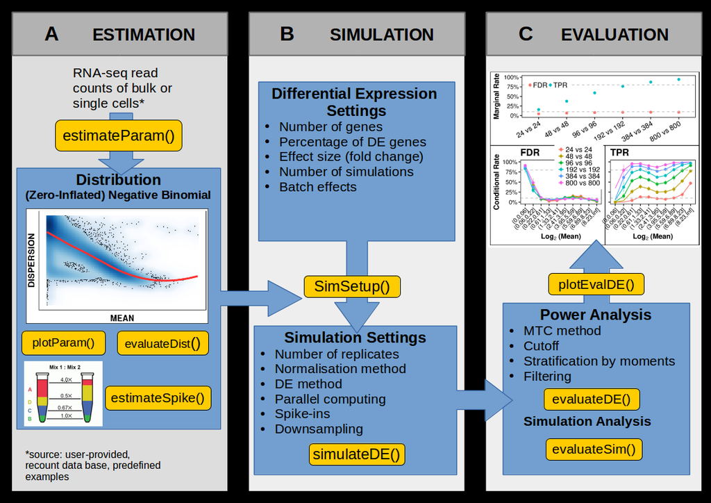

Figure 1: PowsimR schematic overview  
(A) Estimation (B) Simulation (C) Evaluation.

# 3 Parameter Estimation

## 3.1 Gene Expression

The parameters of the (zero-inflated) negative binomial distribution, i.e. mean and dispersion are estimated by the function `estimateParam`. In addition, the dropout probability, i.e. the fraction of zero counts per gene, is calculated. The user can choose between two estimation frameworks:

- Negative binomial distribution (NB)
- Zero-inflated negative binomial distribution (ZINB)

In both cases matching moments estimation of mean and dispersion are based on normalized counts.

The user can choose between multiple normalisation methods (see Details section of `estimateParam`). Furthermore, a number of methods are group sensitive (e.g. batch labels can be provided in SCnorm).

The estimates, sequencing depth and normalisation factors are plotted with `plotParam`.

```r
library("powsimR")
data("kolodziejczk_cnts")
kolodziejczk_cnts <- kolodziejczk_cnts[, grep('standard',
                                              colnames(kolodziejczk_cnts))]
TwoiLIF.params <- estimateParam(countData=kolodziejczk_cnts,
                                batchData = NULL,
                                spikeData = NULL,
                                spikeInfo = NULL,
                                Lengths = NULL,
                                MeanFragLengths = NULL,
                                Distribution = 'ZINB',
                                RNAseq = 'singlecell',
                                normalisation = 'scran',
                                sigma = 1.96,
                                NCores = NULL)
```

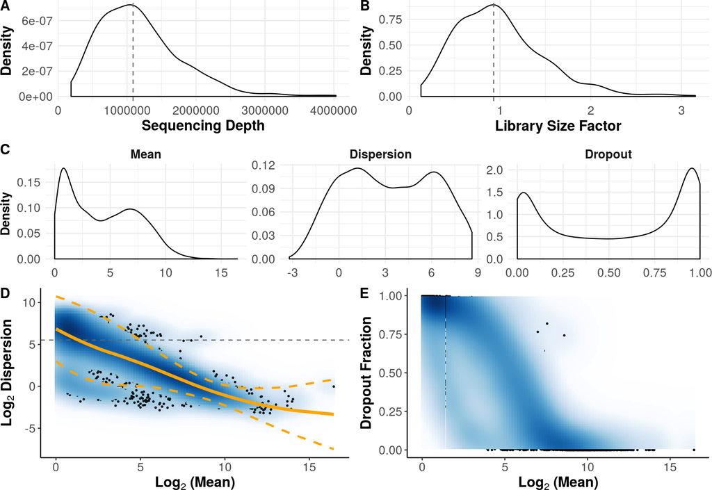

Figure 2: Estimated parameters for Kolodziejczyk data set  
(A) Sequencing depth per sample with median sequencing depth (grey dashed line). (B) Library size normalisation factor per sample with median size factor (grey dashed line). (C) Marginal Distribution of log2(mean), log2(dispersion) and dropout. (D) Local polynomial regression fit between log2(mean) and log2(dispersion) estimates with variability band per gene (yellow). Common dispersion estimate (grey dashed line). E) Fraction of dropouts versus estimated mean expression per gene.

```r
plotParam(TwoiLIF.params, annot = F)
```

We have implemented a read count simulation framework assuming either a negative binomial distribution or a zero-inflated negative binomial distribution. To predict the dispersion given a random draw of mean expression value observed, we apply a locally weighted polynomial regression fit. To capture the variability of dispersion estimates observed, a local variability prediction band is applied. For bulk RNA-seq experiments, dropouts are less probable but can still occur. To include this phenomenon we sample from the observed dropout rates for genes that have a mean expression value below 5% dropout probability determined by a decrease constrained B-splines regresssion of dropout rate against mean expression (`cobs` in *cobs*). The resulting read count matrix has similar distributional characteristics as the original Kolodziejczyk data set (Figure 3). For the zero-inflated negative binomial distribution, the mean-dispersion relation is similarly estimated, but based on positive read counts. Furthermore, the dropouts are also predicted based on a locally weighted polynomial regression fit between mean and dropouts. Of note, this fit is done separately for amplified and non-amplified transcripts separately and similar proportions of genes as observed are also generated in the simulations (Ziegenhain et al. 2017). We have found that the negative binomial distribution is particularly suited for UMI-methods (e.g. SCRB-Seq, Drop-Seq, 10XGenomics) (Vieth et al. 2017).

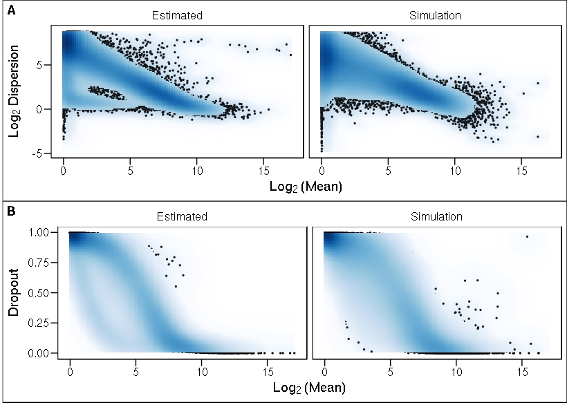

Figure 3: Comparison of estimated and simulated read counts  
(A) Dispersion versus Mean. (B) Dropout versus Mean.

## 3.2 Spike-ins

Some normalisation methods can use spike-ins as part of their normalisation (e.g. SCnorm, scran, Census). To use spike-in information in the simulations, their distributional characteristics need to be estimated. We follow the estimation and simulation framework presented in (Kim et al. 2015) where the variance is decomposed into shot noise and mRNA loss due to capture and sequencing efficiency. In short, the parameters for a Beta-distribution describes the RNA molecule capture efficiency and the parameters of a Gamma distribution describes the sequencing efficiency, which we can then use to simulate in silico spike-ins given a mean expression value. We assume that biological variance does not contribute to spike-in expression. The user needs to define the spike-in expression table and the spike-in information table (IDs, molecules, lengths per spike-in) in the function `estimateSpike`. The following formula can help the user to calculate the number of molecules of spike-ins:

$$\begin{equation}
Y_{j} = c_{j} * V * 10^{-3} * D^{-1} * 10^{-18} * {Avogadro}, \quad j=1,\dots,92
\end{equation}$$

The number of molecules $Y_{j}$ for each ERCC spike-in species is the product of the molar concentration $c_{j}$ (attomoles per microlitre), the dilution factor $1/D$, the volume $V$ (nanolitre), Avogadros’ constant ($6.02214129*10^{23}$) and conversion factors between unit scales.

With the following command, we estimate the parameters for the spike-ins added to the library preparation of embryonic stem cells cultured in standard 2i+lif medium (Ziegenhain et al. 2017). Descriptive plots of the spike-ins can be drawn with `plotSpike` (Figure 4).

```r
data("scrbseq_spike_cnts")
data("scrbseq_spike_info")
batch_info <- data.frame(Batch = ifelse(grepl(pattern = "SCRBseqA_", colnames(scrbseq_spike_cnts)), "A", "B"), row.names = colnames(scrbseq_spike_cnts))
## spike information table
spike_info <- scrbseq_spike_info[-1,]
## estimation
spike.param <- estimateSpike(spikeData = scrbseq_spike_cnts,
                             spikeInfo = spike_info,
                             MeanFragLength = NULL,
                             batchData = batch_info,
                             normalisation = 'depth')
```

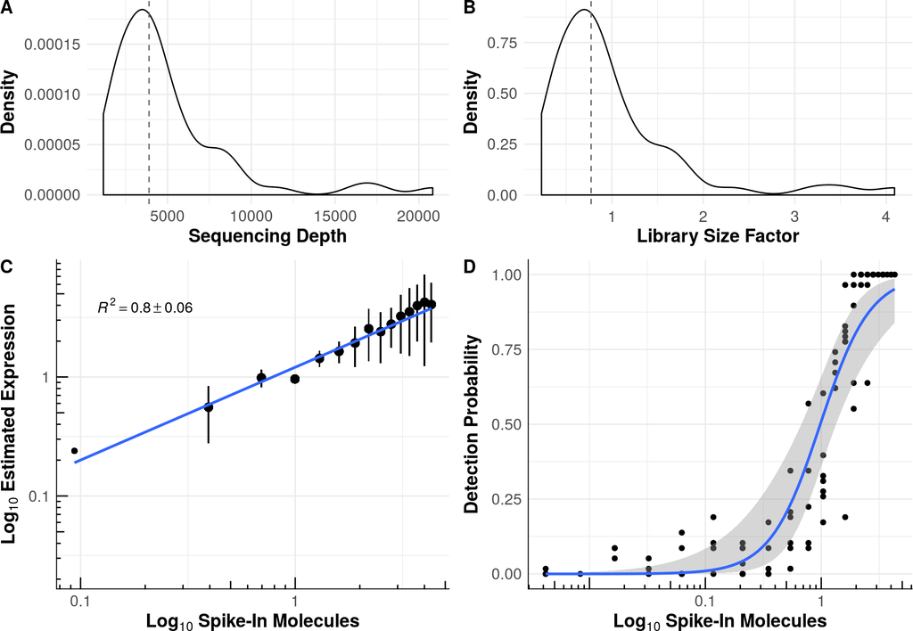

Figure 4: Estimated parameters for the spike-ins added to SCRBseq libraries in Ziegenhain dataset  
(A) Sequencing depth per sample with median sequencing depth (grey dashed line). (B) Library size normalisation factor per sample with median size factor (grey dashed line). (C) Calibration curve with mean expression estimates and average R squared over all cells. (D) Capture efficiency with binomial logistic regression fit over all cells.

```r
plotSpike(spike.param, annot = F)
```

# 4 Simulations

For simulating differential expression between two groups, the number of genes, number of simulations, percentage of differential expression and effect size are set up with the function `DESetup`. The effect size is here defined as the log2 fold change which can be a constant, sampled from a vector or function. The uniform, normal and gamma distributions are possible options and illustrated in figure 5. Depending on the settings, these distribution can be broader or narrower. If using this option, we recommend to choose a distribution that closely resembles previously observed or expected fold changes. There is also the possibility to include batch effects.

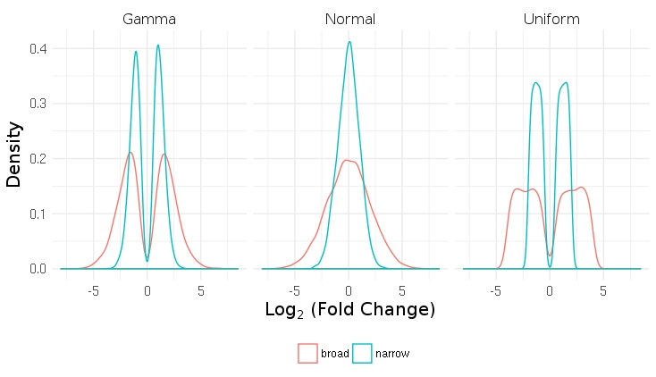

Figure 5: Log2 fold change examples for gamma, uniform and normal distribution

The distribution estimates and these settings are then combined to one object with `SimSetup`. This allows the user to assess power of multiple groupwise comparisons and different differential testing methods. The following command sets up simulations with 10,000 genes, 20% genes being DE, log fold change sample from a narrow gamma distribution and parameter estimates based on Kolodziejczyk data.

```r
lfc.gamma = function(x) sample(c(-1,1), size=x,replace=T)*rgamma(x, 3, 3)
de.opts = DESetup(ngenes=10000, nsims=25,
                  p.DE=0.2, pLFC=lfc.gamma,
                  sim.seed = 58673)
sim.opts = SimSetup(desetup = de.opts,
                    params = TwoiLIF.params,
                    spike=NULL,
                    size.factors='equal',
                    downsample=FALSE, geneset = FALSE)
```

There are also additional options: Whether to apply a prefiltering or imputation step prior to normalisation; whether spike-in information should be used (if available). For more information, please consult the Details section of `simulateDE`.

```r
simDE = simulateDE(n1 = c(24,48,96,192,384,800),
                   n2 = c(24,48,96,192,384,800),
                   sim.settings = sim.opts,
                   DEmethod = "limma-trend",
                   normalisation = "scran",
                   Preclust = FALSE,
                   Prefilter = NULL,
                   Impute = NULL,
                   spikeIns = FALSE,
                   NCores = NULL,
                   verbose = TRUE)
```

# 5 Evaluation

The results of differential expression simulation are evaluated with `evaluateDE`. We have separated the evaluation from DE detection to allow the user to evaluate power in a comprehensive way as advocated by (H. Wu, Wang, and Wu 2015). In this function, the proporations and error rates are estimated. The rates can be stratified by mean, dispersion dropout or log fold change. Furthermore, the user can choose between different multiple testing correction methods (see `p.adjust.methods`, `ihw` in *IHW* and `qvalue` in *qvalue*). Also, the genes can be filtered by mean, dispersion or dropout. To define biologically interesting genes, a cutoff for the log2 fold change with `delta` can be set.

With the following command we evaluate the marginal TPR and FDR conditional on the mean expression for the simulation based on Kolodziejczyk data. For this example, a smaller example simulation run is loaded.

```r
data("kolodziejczk_simDE")
simDE = kolodziejczk_simDE
evalDE = evaluateDE(simRes = simDE,
                     alpha.type = 'adjusted',
                     MTC = 'BH',
                     alpha.nominal = 0.1,
                     stratify.by = 'mean',
                     filter.by = 'none',
                     strata.filtered = 1,
                     target.by = 'lfc',
                     delta = 0)
```

The results of the evaluation can be plotted with `plotEvalDE`.

- **rate:** The user can choose to plot the marginal or stratified error rates. The number of genes per stratum are also summarised.
- **quick:** If this is set to `TRUE` then only the TPR and FDR will be plotted.

With the following commands, the quick marginal and conditional power assessment for the Kolodziejczyk data is plotted (Figurer 6 and 7).

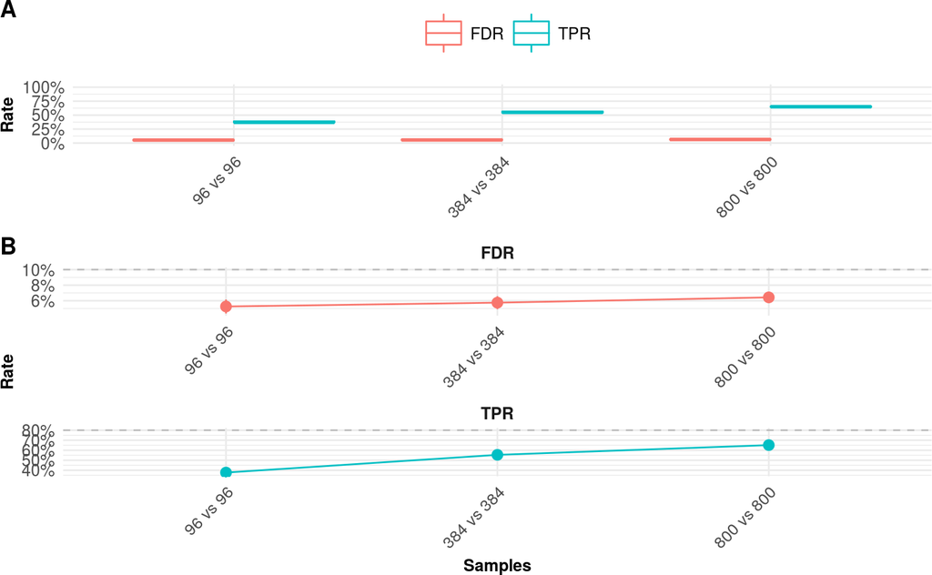

Figure 6: Marginal Error Rates  
(A) Marginal TPR and FDR per sample size comparison. (B) Marginal TPR and FDR per sample size comparison with dashed line indicating nominal alpha level (type I error) and nominal 1-beta level, i.e. 80% power (type II error).

```r
plotEvalDE(evalRes = evalDE,
            rate='marginal',
            quick=TRUE, annot=FALSE)
```

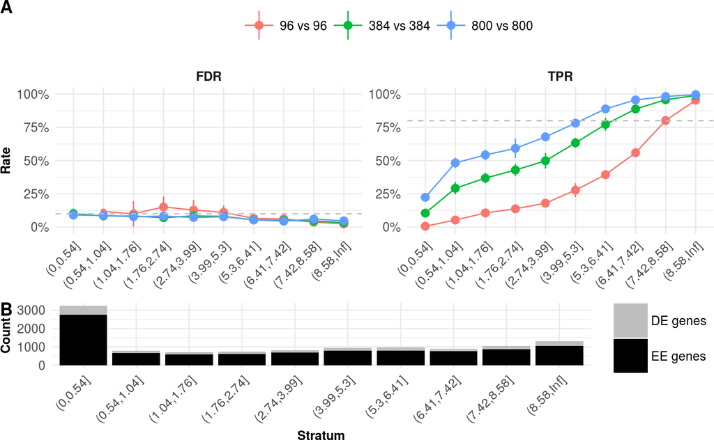

Figure 7: Stratified Error Rates  
(A) Conditional TPR and FDR per sample size comparison per stratum. (B) Number of equally (EE) and differentially expressed (DE) genes per stratum.

```r
plotEvalDE(evalRes = evalDE,
            rate='stratified',
            quick=TRUE, annot=FALSE)
```

# 6 Additional Functionalities

## 6.1 Read Count Matrices

Some users might be interested in outputting only simulated read counts by calling `simulateCounts`. With this function, users can also simulate multiple groups of samples. To define meaningful log2 fold change differences between the groups, I recommend to use multivariate distributions with a defined covariance structure.

One can also have a quick visualisation of the simulated counts with `plotCounts`.

Here a small example for simulating a data set containing two groups with batch effects (Figure 8).

```r
plfc.foo = function(x) sample(c(-1,1), size=x, prob = c(0.25,0.75),replace=T)*
  rgamma(x, 2, 4)
blfc.foo = function(x) rnorm(x, sd = 0.25)
simcounts.2grp <- simulateCounts(n=c(120, 100),
                                 ngenes=10000,
                                 p.DE=0.1, pLFC=plfc.foo,
                                 p.B=0.1, bLFC=blfc.foo,
                                 bPattern="uncorrelated",
                                 p.M=NULL, mLFC=NULL,
                                 params=kolodziejczk_param,
                                 spike=NULL,
                                 spikeIns=FALSE,
                                 size.factors="given",
                                 downsample=F,
                                 geneset=F,
                                 sim.seed=NULL,
                                 verbose=TRUE)
```

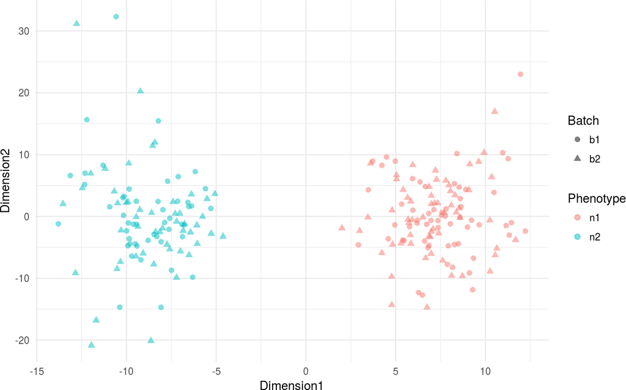

Figure 8: PCA plot showing two simulated groups

With this function, we can also simulate single cell populations (Figure 9). In the following section the expression profiles of embryonic stem cells grown in different media are used as an example. The covariance matrix of log2 fold changes needs to be provided and forms the basis for simulating cell populations differing in expression by a multivariate normal distribution of fold changes:

```r
if(length(grep("MBESS",installed.packages()))==0){
   install.packages("MBESS", dependencies = TRUE, repos = "https://cran.rstudio.com/")
}
if(length(grep("mvtnorm",installed.packages()))==0){
   install.packages("mvtnorm", dependencies = TRUE, repos = "https://cran.rstudio.com/")
 }
cor.lfc <- matrix(c(1,0.5,0.7,0.5,1,0.95,0.7,0.95,1), nrow=3, ncol=3)
v.lfc <- c(4,1,1)
cov.lfc <- MBESS::cor2cov(cor.lfc,v.lfc)

plfc.foo = function(x) {
  mu.tmp = stats::rnorm(n = ncol(cov.lfc), mean = 0, sd = 0.5)
  mvtnorm::rmvnorm(x, mean = mu.tmp, sigma = cov.lfc)
}

simcounts.3grp <- simulateCounts(n=c(100, 50, 50),
                                 ngenes=10000,
                                 p.DE=0.1, pLFC=plfc.foo,
                                 p.B=NULL, bLFC=NULL,
                                 bPattern="uncorrelated",
                                 p.M=NULL, mLFC=NULL,
                                 params=kolodziejczk_param,
                                 spike=NULL,
                                 spikeIns=FALSE,
                                 size.factors="given",
                                 downsample=F,
                                 geneset=F,
                                 sim.seed=NULL,
                                 verbose=TRUE)
```

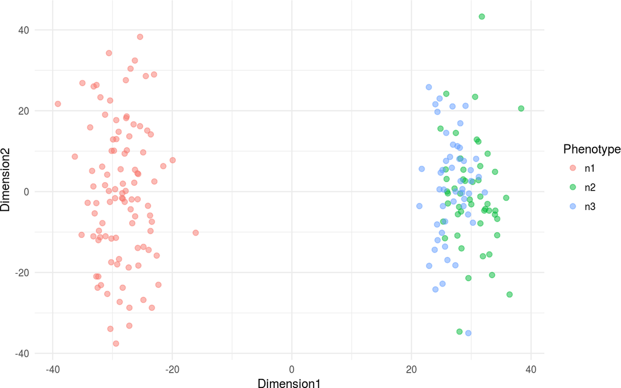

Figure 9: PCA plot showing three simulated groups

## 6.2 Negative Binomial Parameters

### 6.2.1 in silico Parameter Definition

We have also implemented the option to approximate the read count matrix simulation based on random distribution functions in *R*. The user then has to define the mean, dispersion, dropout and library size in `insilicoNBParam`. In the absence of suitable pilot studies, a typical single cell RNA-seq experiment could be approximated with:

- mean: `function(x) rgamma(x, 4, 2)` where x is the number of genes
- dispersion: `function(x) 2 + 100/x` where x is the mean
- library size: `function(x) 2*rnorm(n=x, mean=0, sd=0.25)` where x is the number of samples

The same functionality can also be used for bulk RNA-seq.

### 6.2.2 Count matrices of single cell RNA-seq experiments

We have uploaded read count matrices of 5 single cell RNA-seq experiments on [github](https://github.com/bvieth/powsimRData). The user can calculate the negative binomial parameters with `estimateParam`, view these estimates with `plotParam` and use it as an input for `SimSetup`.

### 6.2.3 Access to raw read counts stored in online data base

We have provided a number of exemplatory single cell RNA-seq data sets for parameter estimation. Nevertheless, you might not find a data set that matches your own experimental setup. In those cases, we recommend to check online repositories for a suitable data set. Below you can find an example script to get count tables from [recount2](https://jhubiostatistics.shinyapps.io/recount/) (Collado-Torres et al. 2017). For a single cell RNA-seq data base, see [conquer](http://imlspenticton.uzh.ch:3838/conquer/) (Soneson and Robinson 2018). As before, the user can then estimate the negative binomial parameters with `estimateParam`, view these estimates with `plotParam` and use it as an input for `SimSetup`.

```r
# Install and load the R package
source('http://bioconductor.org/biocLite.R')
biocLite('recount')
library('recount')

# Download the data set
url <- download_study('SRP060416')

# Load the data
load(file.path('SRP060416', 'rse_gene.Rdata'))

# count table
cnts <- assay(rse_gene)
# sample annotation
sample.info <- data.frame(colData(rse_gene)@listData, stringsAsFactors=F)
# gene annotation
gene.info <- data.frame(GeneID=rowData(rse_gene)@listData$gene_id, GeneLength=rowData(rse_gene)@listData$bp_length, stringsAsFactors=F)
```

## 6.3 Simulation Settings

By default, there is no difference in library sizes between the samples. If the user wishes for a more realistic, i.e. more variable distribution of read counts across samples, the library sizes can be sampled from observed, vector or function.

## 6.4 Evaluate Simulation Framework

It is important to validate the appropiateness of the chosen simulation framework. The function `evaluateDist` compares the theoretical fit of the Poisson, negative binomial, zero-inflated Poisson and zero-inflated negative binomial and beta-Poisson distribution to the empirical RNA-seq read counts ((Colin Cameron and Trivedi 2013), (Kim and Marioni 2013), (Delmans and Hemberg 2016)). The evaluation is then plotted with the function `plotEvalDist` which summarizes the best fitting distribution per gene based on goodness-of-fit statistics (Chi-square test), Akaike Information Criterium, comparing observed dropouts with zero count prediction of the models and comparing the model fitness with Likelihood Ratio Test and Vuong Test. As noted by other developers, goodness-of-fit tests are not an objective tool and heavily depend on sample sizes (Delignette-Muller and Dutang 2015). A graphical evaluation of the fitted distribution is considered the most appropiate way but for high-throughput sequencing this is an unrealistic recommendation. Bulk RNA-seq experiments are usually conducted with a small number of samples. We therefore recommend to rely on the goodness-of-fit validation by (Mi, Di, and Schafer 2015).

With the following command, we determine and plot the fitting for the embryonic stem cells cultured in standard 2i lif medium (Kolodziejczyk et al. 2015). Note that the results shown in Figure 10 will differ from the executed command since I reduced the data set and evaluate the fitting only for a fraction of genes.

```r
library("powsimRDev")
data("kolodziejczk_cnts")
kolodziejczk_cnts <- kolodziejczk_cnts[, grep('standard',
                                              colnames(kolodziejczk_cnts))]
TwoiLIF.dist <- evaluateDist(countData = kolodziejczk_cnts,
                             batchData = NULL,
                             spikeData = NULL,
                             spikeInfo = NULL,
                             Lengths = NULL,
                             MeanFragLengths = NULL,
                             RNAseq = 'singlecell',
                             normalisation = 'scran',
                             frac.genes = 0.2,
                             min.meancount = 0.1,
                             max.dropout = 0.8,
                             min.libsize = 1000,
                             verbose = TRUE)
```

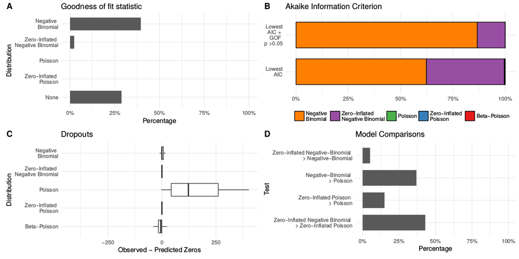

Figure 10: Distribution Evaluation  
A) Goodness-of-fit of the model assessed with a Chi-Square Test based on residual deviance and degrees of freedom. B) Akaike Information Criterion per gene: Model with the lowest AIC. Model with the lowest AIC and passed goodness-of-fit statistic test. C) Observed versus predicted dropouts per model and gene plotted without outliers. D) Model Assessment based on LRT for nested models and Vuong test for nonnested models.

# References

Colin Cameron, A, and Pravin K Trivedi. 2013. *Regression Analysis of Count Data (Econometric Society Monographs)*. 2 edition. Cambridge University Press.

Collado-Torres, Leonardo, Abhinav Nellore, Kai Kammers, Shannon E Ellis, Margaret A Taub, Kasper D Hansen, Andrew E Jaffe, Ben Langmead, and Jeffrey T Leek. 2017. “Reproducible RNA-seq Analysis Using Recount2.” *Nat. Biotechnol.* 35 (4): 319–21. doi:10.1038/nbt.3838.

Delignette-Muller, Marie, and Christophe Dutang. 2015. “Fitdistrplus: An R Package for Fitting Distributions.” *J. Stat. Softw.* 64 (1): 1–34. doi:10.18637/jss.v064.i04.

Delmans, Mihails, and Martin Hemberg. 2016. “Discrete Distributional Differential Expression (D3E)–a Tool for Gene Expression Analysis of Single-Cell RNA-seq Data.” *BMC Bioinformatics* 17 (29~feb): 110. doi:10.1186/s12859-016-0944-6.

Kim, Jong Kyoung, and John C Marioni. 2013. “Inferring the Kinetics of Stochastic Gene Expression from Single-Cell RNA-sequencing Data.” *Genome Biol.* 14 (1): R7. doi:10.1186/gb-2013-14-1-r7.

Kim, Jong Kyoung, Aleksandra A Kolodziejczyk, Tomislav Illicic, Sarah A Teichmann, and John C Marioni. 2015. “Characterizing Noise Structure in Single-Cell RNA-seq Distinguishes Genuine from Technical Stochastic Allelic Expression.” *Nat. Commun.* 6 (22~oct): 8687. doi:10.1038/ncomms9687.

Kolodziejczyk, Aleksandra A, Jong Kyoung Kim, Jason C H Tsang, Tomislav Ilicic, Johan Henriksson, Kedar N Natarajan, Alex C Tuck, et al. 2015. “Single Cell RNA-Sequencing of Pluripotent States Unlocks Modular Transcriptional Variation.” *Cell Stem Cell* 17 (4): 471–85. doi:10.1016/j.stem.2015.09.011.

Mi, Gu, Yanming Di, and Daniel W Schafer. 2015. “Goodness-of-Fit Tests and Model Diagnostics for Negative Binomial Regression of RNA Sequencing Data.” *PLoS One* 10 (3): e0119254. doi:10.1371/journal.pone.0119254.

Soneson, Charlotte, and Mark D Robinson. 2018. “Bias, Robustness and Scalability in Single-Cell Differential Expression Analysis.” *Nat. Methods*, February. doi:10.1038/nmeth.4612.

Vieth, Beate, Christoph Ziegenhain, Swati Parekh, Wolfgang Enard, and Ines Hellmann. 2017. “PowsimR: Power Analysis for Bulk and Single Cell RNA-seq Experiments.” *Bioinformatics* 33 (21): 3486–8. doi:10.1093/bioinformatics/btx435.

Wu, Hao, Chi Wang, and Zhijin Wu. 2015. “PROPER: Comprehensive Power Evaluation for Differential Expression Using RNA-seq.” *Bioinformatics* 31 (2): 233–41. doi:10.1093/bioinformatics/btu640.

Ziegenhain, Christoph, Beate Vieth, Swati Parekh, Björn Reinius, Amy Guillaumet-Adkins, Martha Smets, Heinrich Leonhardt, Holger Heyn, Ines Hellmann, and Wolfgang Enard. 2017. “Comparative Analysis of Single-Cell RNA Sequencing Methods.” *Mol. Cell* 65 (4): 631–643.e4. doi:10.1016/j.molcel.2017.01.023.